# 07.Example 1

Modified

Mo 2023-09-25 17:14

## Given and Required:

Using the energy balance method, derive the finite-difference equation for the ($m$, $n$) nodal point located on a plane, insulated surface of a medium with uniform heat generation.

## Solution:

A sketch of the system is shown below.

Figure 1: System Sketch

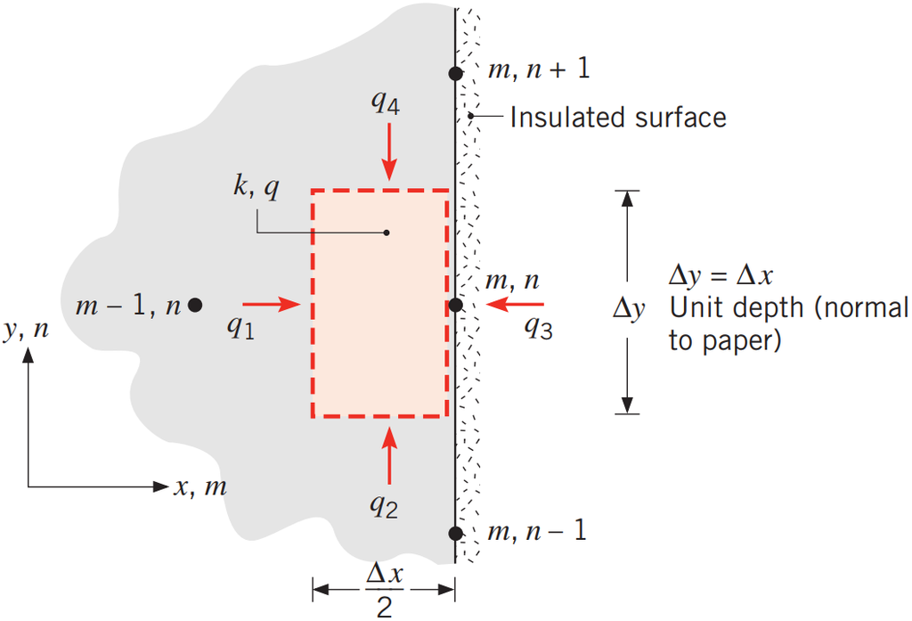

Applying the energy balance to the control volume of size $\frac{\Delta x}{2} \cdot \Delta y \cdot 1$ shows

$$q_1 + q_2 + q_3 + q_4 + \dot{q}\left( \frac{\Delta x}{2} \cdot \Delta y \cdot 1 \right) = 0$$

Begining with $q_1$, it may be seen that this is from node ($m - 1$, $n$) to node ($m$, $n$). This arrangement is simple conduction. Thus

$$q_1 = k \left( \Delta y \cdot 1 \right) \frac{T_{m - 1, n} - T_{m, n}}{\Delta x}$$

The heat $q_2$ goes between nodes ($m$, $n - 1$) and ($m$, $n$). This arrangement is again simple conduction. Thus,

$$q_2 = k \left( \frac{\Delta x}{2} \cdot 1 \right) \frac{T_{m, n - 1} - T_{m, n}}{\Delta y}$$

The heat $q_3$ is on the insulated surface (i.e., it’s an adiabatic surface) and thus is by definition equal to zero (i.e., $q_3 = 0$). Finally, the heat $q_4$ is between nodes ($m$, $n + 1$) and ($m$, $n$). This arrangement is once again simple conduction so

$$q_4 = k \left( \frac{\Delta x}{2} \cdot 1 \right) \frac{T_{m, n + 1} - T_{m, n}}{\Delta y}$$

Combining all of these expressions into the energy balance expression yields

$$k \left( \Delta y \cdot 1 \right) \frac{T_{m - 1, n} - T_{m, n}}{\Delta x} + k \left( \frac{\Delta x}{2} \cdot 1 \right) \frac{T_{m, n - 1} - T_{m, n}}{\Delta y} + 0 + k \left( \frac{\Delta x}{2} \cdot 1 \right) \frac{T_{m, n + 1} - T_{m, n}}{\Delta y} + \dot{q}\left( \frac{\Delta x}{2} \cdot \Delta y \cdot 1 \right) = 0$$

Since $\Delta y = \Delta x$, the above expression may be simplified to

$$k \left( T_{m - 1, n} - T_{m, n} \right) + \frac{k}{2} \left( T_{m, n - 1} - T_{m, n} \right) + \frac{k}{2} \left( T_{m, n + 1} - T_{m, n} \right) + \frac{\dot{q}}{2} \left( \Delta x \right)^2 = 0$$

Dividing everything by $\frac{k}{2}$ shows

$$2 \left( T_{m - 1, n} - T_{m, n} \right) + T_{m, n - 1} - T_{m, n} + T_{m, n + 1} - T_{m, n} + \frac{\dot{q}}{k} \left( \Delta x \right)^2 = 0$$

Collecting like terms yields the final solution

Answer: $2 T_{m - 1, n} + T_{m, n - 1} + T_{m, n + 1} - 4 T_{m, n} + \frac{\dot{q}}{k} \left( \Delta x \right)^2 = 0$